# SOL-data-munging-analysis

Kyle MacDonald

September 8, 2014

## Data processing, plotting, and analysis script for SOL PEEK data

Clear workspace

```r
rm(list=ls())
```

### Read in data and do some minor cleaning

Load libraries

```r
source("../helpers/libraries_v_3.6.R")
```

```
## [1] "loading library"
```

```r
source("../helpers/useful.R")
```

```r
iChart <- read.csv("processed_data/sol-ichart-vanilla-n76.csv",
                   check.names=F, stringsAsFactors=F)
```

### Data processing and filtering

Load demographics table.

```r
sol_demo <- read.csv("../../raw_data/sol_demo_all.csv")
sol_demo$reason_excluded <- as.character(sol_demo$reason_excluded)
```

One child completed two PEEKs because the fire alarm went off after first 8 trials in PEEK1 – here, we read in the data as two subjects (30036 and 99999) and now we revalue subject 99999 to be 30036.

After running this, 30036 should have 22 vanilla trials and 99999 should no longer exist.

```r
iChart$Sub.Num[iChart$Sub.Num == "99999"] <- "30036"
```

Filter out participants that should not go into analyses based on exclusionary criteria: a) age, b) didn’t know signs in the task, c) not enough ASL exposure.

```r
include <- select(sol_demo, Sub.Num, stimuli, include, reason_excluded, age_code, peek_data, cdi_data)
iChart <- merge(iChart, include, by = c("Sub.Num", "stimuli"))
iChart <- filter(iChart, include == "yes")
```

Get descriptives: the number of trials for each subject, ages, genders.

```r
descriptives <- iChart %>%
    group_by(Sub.Num, Months, Sex) %>%
    summarise(Trials = n())
```

### Flag C-T and C-D Trials

Datawiz does not tell us which shifts land on a target vs. a disctractor. So we need to use a function that flags each trial as one of the following:

- C-T: center to target
- C-D: center to distractor
- C-C: center to center (child leaves the signer, goes away, and comes back to signer)
- no-shift

```r
# apply it to each row in our datase
trial_types <- apply(iChart, 1, trial_type_fun)

# merge this information back with the iChart
iChart <- cbind(iChart, trial_types)
```

Get distribution of different trial types

```r
iChart %>% group_by(trial_types) %>% summarise(Trials = n())
```

```
## Source: local data frame [4 x 2]
##
##   trial_types Trials
## 1         C-C     75
## 2         C-D    181
## 3         C-T    962
## 4    no-shift    360
```

### Get median split by age

```r
kids_median_age <- iChart %>%
    filter(age_code == "child") %>%
    summarise(median(Months))

# add median split variable to iChart
iChart$age_group <- ifelse(iChart$Months < kids_median_age[1,1],
                           "< 25 Months",
                           ifelse(iChart$Months >= kids_median_age[1,1] &
                                      iChart$Months <= 36,
                                  "> 25 Months",
                                  "Adults"))
```

Here are the number of participants in each age bin.

```r
iChart %>% group_by(age_group) %>% summarise(n_distinct(Sub.Num))
```

```
## Source: local data frame [3 x 2]
##
##     age_group n_distinct(Sub.Num)
## 1 < 25 Months                  18
## 2 > 25 Months                  18
## 3      Adults                  19
```

### Compute statistics

```r
iChart %>% group_by("0", Response) %>% summarise(Trials = n())
```

```
## Source: local data frame [4 x 3]
## Groups: "0"
##
##   "0" Response Trials
## 1   0        A    276
## 2   0        C   1221
## 3   0        D     34
## 4   0        T     47
```

Next we compute statistics (accuracy and rt) over the filtered iChart.

- Window: 300-2600ms

But first, we need to process the data, removing prescreened out trials and keeping only those trials on which the child was looking at the signer at F0 go into Accuracy and RT computations.

- C: Center
- D: Distractor
- T: Target
- A: Away

includeOffCenter == FALSE -> only include trials child was looking at center at F0

includeOffCenter == TRUE -> include trials child was looking at center, target, or distractor at F0

```r
# change all trials to "Vanilla"
iChart$Condition <- "Vanilla"

## remove prescreened out trials
iChart <- filter(iChart, Prescreen.Notes == "")

## define critical onset, change Cs to Ds and everything else to As
iChart <- defineOnsetSOL(iChart, critonset=0, includeOffCenter=FALSE)

## check iChart after setting response (should only have Ds and As)
iChart %>% group_by(Response) %>% summarise(Trials = n())
```

```
## Source: local data frame [2 x 2]
##
##   Response Trials
## 1        A    112
## 2        D   1221
```

Compute statistics.

```r
# compute gaps
iChart <- computeStatistics(iChart, startWindow=0, endWindow=3000)
```

```
## [1] "### Trials left ###"
## [1] 1300
## [1] 1250
## [1] 1200
## [1] 1150
## [1] 1100
## [1] 1050
## [1] 1000
## [1] 950
## [1] 900
## [1] 850
## [1] 800
## [1] 750
## [1] 700
## [1] 650
## [1] 600
## [1] 550
## [1] 500
## [1] 450
## [1] 400
## [1] 350
## [1] 300
## [1] 250
## [1] 200
## [1] 150
## [1] 100
## [1] 50
## [1] 0
```

```r
# reject trials with extreme RT and gaps
iChart <- filteriChart(iChart, minRT=300, maxRT=2000, maxfirstgap=15, maxlonggap=15)
```

Get mean accuracy and RT for each participant by condition

```r
acc <- poolData(meanAccuracy(iChart, startWindowAcc=300, endWindowAcc=2600),
                RejectFirstGap=TRUE,RejectLongestGap=TRUE,
                RejectRT=FALSE, color=TRUE, dependent="Accuracy",
                group="age_group", facet="", dodge="",
                xlab="", ylab= "Proportion\n  Looking\n  to target",
                paired=TRUE, miny = 0.2, maxy = 0.80,
                size=13, legend.direction="horizontal",
                legend.position="bottom",
                breaks=c(0.25, 0.50, 0.75))

## Compute reaction time for each age group only on C-T trials
rt <- poolData(filter(iChart, trial_types == "C-T"),
               RejectFirstGap=TRUE, RejectLongestGap=TRUE,
               RejectRT=TRUE, color=FALSE, dependent="RT", group="age_group",
               facet="", dodge="Response",
               xlab="", ylab="mean RT (ms)",
               paired=TRUE,
               miny = 400, maxy=1300,
               size=13,
               legend.direction = "horizontal",
               legend.position="bottom",
               breaks=c(400, 800, 1200))
```

Get mean accuracy and RT for each participant. Here we don’t split by condition because we will use this for subject level (correlational) analyses later.

```r
acc_ss <- poolData(meanAccuracy(iChart, startWindowAcc=300, endWindowAcc=2000),
                RejectFirstGap=TRUE,RejectLongestGap=TRUE,
                RejectRT=FALSE, color=TRUE, dependent="Accuracy",
                group="", facet="", dodge="",
                xlab="", ylab= "Proportion\n  Looking\n  to target",
                paired=TRUE, miny = 0.2, maxy = 0.80,
                size=13, legend.direction="horizontal",
                legend.position="bottom",
                breaks=c(0.25, 0.50, 0.75))

## Compute reaction time for each age group only on C-T trials
rt_ss <- poolData(filter(iChart, trial_types == "C-T"),
               RejectFirstGap=TRUE, RejectLongestGap=TRUE,
               RejectRT=TRUE, color=FALSE, dependent="RT", group="",
               facet="", dodge="Response",
               xlab="", ylab="mean RT (ms)",
               paired=TRUE,
               miny = 400, maxy=1300,
               size=13,
               legend.direction = "horizontal",
               legend.position="bottom",
               breaks=c(400, 800, 1200))
```

## Statistics

Get mean accuracy and rt for each participant

Some munging to get data frame for analysis. Variables needed for each subject: * Mean acc * Mean rt * Signs produced * Age * Age condition

```r
# merge acc/rt van1
ss <- merge(acc_ss, rt_ss, by="Sub.Num")

# merge with demo info
ss <- merge(ss, filter(sol_demo, include=="yes"), by="Sub.Num")

# get age bins
ss_age_bins <- iChart %>%
    select(Sub.Num, age_group) %>%
    distinct()

ss <- merge(ss, ss_age_bins, by="Sub.Num")

# clean up variable names in data frame
names(ss)[names(ss)=="Vanilla"] <- "mean_accuracy"
names(ss)[names(ss)=="Vanilla_D"] <- "mean_ct_rt"
```

Set up filter to just include kids for correlation analyses.

```r
ss_kids <- filter(ss, age_group != "Adults")
```

Next we compute correlations between linguistic processing efficiency measures (acc, rt) and age.

```r
cor.test(ss_kids$mean_accuracy, ss_kids$age_months, method = "pearson")
```

```
##
##  Pearson's product-moment correlation
##
## data:  ss_kids$mean_accuracy and ss_kids$age_months
## t = 2.0345, df = 34, p-value = 0.04976
## alternative hypothesis: true correlation is not equal to 0
## 95 percent confidence interval:
##  0.001010011 0.593713577
## sample estimates:
##       cor
## 0.3294364
```

Correlation between accuracy and vocabulary.

```r
cor.test(ss_kids$signs_produced, ss_kids$mean_accuracy, method = "pearson")
```

```
##
##  Pearson's product-moment correlation
##
## data:  ss_kids$signs_produced and ss_kids$mean_accuracy
## t = 1.6927, df = 32, p-value = 0.1002
## alternative hypothesis: true correlation is not equal to 0
## 95 percent confidence interval:
##  -0.05702133  0.56961760
## sample estimates:
##       cor
## 0.2866722
```

Correlation between rt and vocabulary.

```r
cor.test(ss_kids$signs_produced, ss_kids$mean_ct_rt, method = "pearson")
```

```
##
##  Pearson's product-moment correlation
##
## data:  ss_kids$signs_produced and ss_kids$mean_ct_rt
## t = -1.5967, df = 32, p-value = 0.1202
## alternative hypothesis: true correlation is not equal to 0
## 95 percent confidence interval:
##  -0.5585087  0.0732452
## sample estimates:
##       cor
## -0.271649
```

## Paper ready scatter plots

Acc-vocab scatter

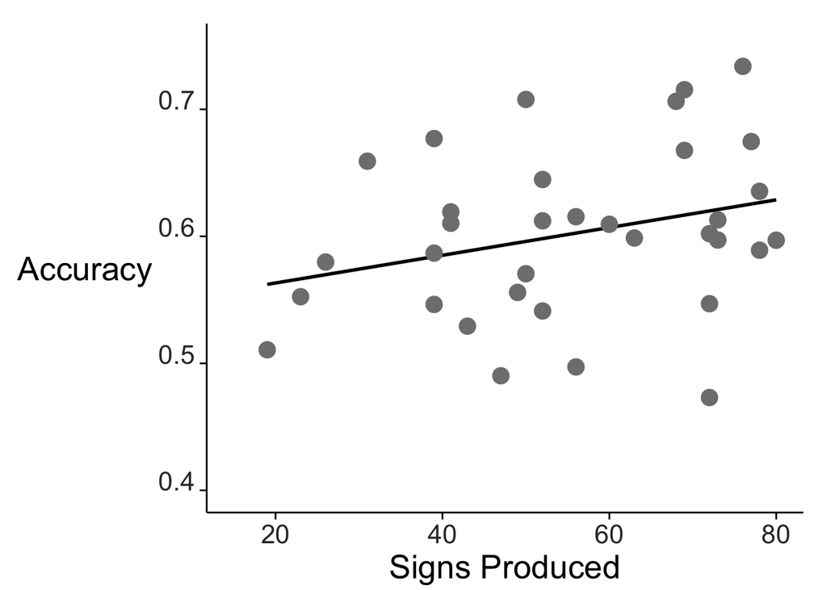

```r
qplot(data=ss_kids, x=signs_produced, y=mean_accuracy) +
    geom_smooth(method="lm", se=FALSE, color="black", size=1) +
    geom_point(colour="grey50", size=5) +
    xlab("Signs Produced") +
    xlim(15,80) +
    ylim(0.4,0.75) +
    ylab("Accuracy") +
    theme_classic() +
    theme(axis.title.x = element_text(colour="black",size=20,
                                      angle=0,hjust=0.5,vjust=0,face="plain"),
          axis.title.y = element_text(colour="black",size=20,
                                      angle=0,hjust=0.5,vjust=0.5,face="plain"),
          axis.text.x = element_text(colour="grey20",size=16,
                                     angle=0,hjust=0.5,vjust=0,face="plain"),
          axis.text.y = element_text(colour="grey20",size=16,
                                     angle=0,hjust=0.5,vjust=0,face="plain"))
```

RT-vocab scatter

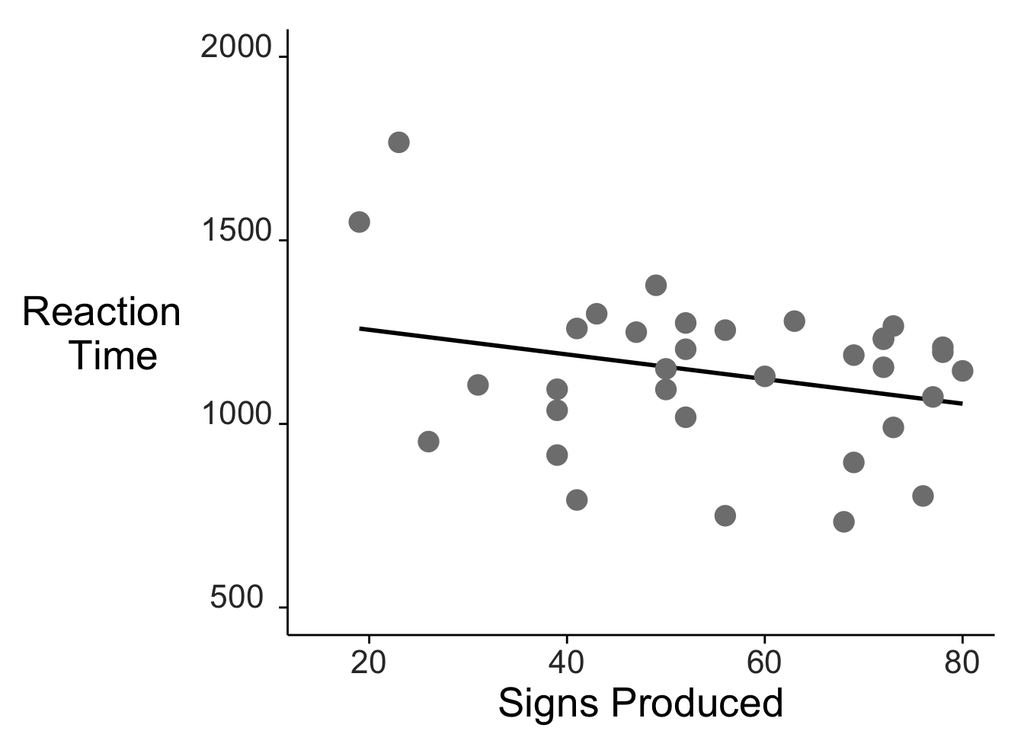

```r
qplot(data=ss_kids, x=signs_produced, y=mean_ct_rt) +
    geom_smooth(method="lm", se=F, color="black", size=1) +
    geom_point(color="grey50", size=5) +
    xlab("Signs Produced") +
    ylim(500, 2000) +
    xlim(15,80) +
    ylab("Reaction \n Time") +
    theme_classic() +
    theme(axis.title.x = element_text(colour="black",size=20,
                                      angle=0,hjust=0.5,vjust=0,face="plain"),
          axis.title.y = element_text(colour="black",size=20,
                                      angle=0,hjust=0.5,vjust=0.5,face="plain"),
          axis.text.x = element_text(colour="grey20",size=16,
                                     angle=0,hjust=0.5,vjust=0,face="plain"),
          axis.text.y = element_text(colour="grey20",size=16,
                                     angle=0,hjust=0.5,vjust=0,face="plain"))
```

## Group-level statistics

```r
t.test(mean_accuracy ~ age_group, data=ss_kids)
```

```
##
##  Welch Two Sample t-test
##
## data:  mean_accuracy by age_group
## t = -1.1939, df = 33.677, p-value = 0.2409
## alternative hypothesis: true difference in means is not equal to 0
## 95 percent confidence interval:
##  -0.07185798  0.01868466
## sample estimates:
## mean in group < 25 Months mean in group > 25 Months
##                 0.5867221                 0.6133088
```

## Individual subs profile plots

Exploratory – see what’s going on with each participant

```r
ss.et <- read.table("sol-ichart-vanilla1-n41_PP_graphValues_by_subs_0_4000_minRT_33_maxRT_2967_lg_14_fg_10_n_55.txt", header = T)
```

Some munging.

```r
detach("package:reshape", unload=TRUE)

#strip X from header
names(ss.et) <- gsub("X", "", names(ss.et))

#get ages and vocabulary from demo, rename id to Sub.Num, and merge with graph values,
age.voc <- sol_demo %>%
    filter(include == "yes") %>%
    select(Sub.Num, age_months, signs_produced, stimuli)

ss.et <- left_join(ss.et, age.voc, by="Sub.Num")

#melt to long form for plotting
ss.et.long <- melt(ss.et,
                   id.vars=c("Sub.Num", "Condition",
                             "age_months", "signs_produced",
                             "groupping", "stimuli"),
                   variable.name = "Time.ms",
                   value.name = "accuracy")

#convert sub.num to a factor
ss.et.long <- ss.et.long %>%
    mutate(Sub.Num = as.factor(Sub.Num),
           Time.ms = as.numeric(as.character(Time.ms)),
           age_months = as.factor(age_months),
           accuracy = as.numeric(accuracy))
```

Plot younger kids

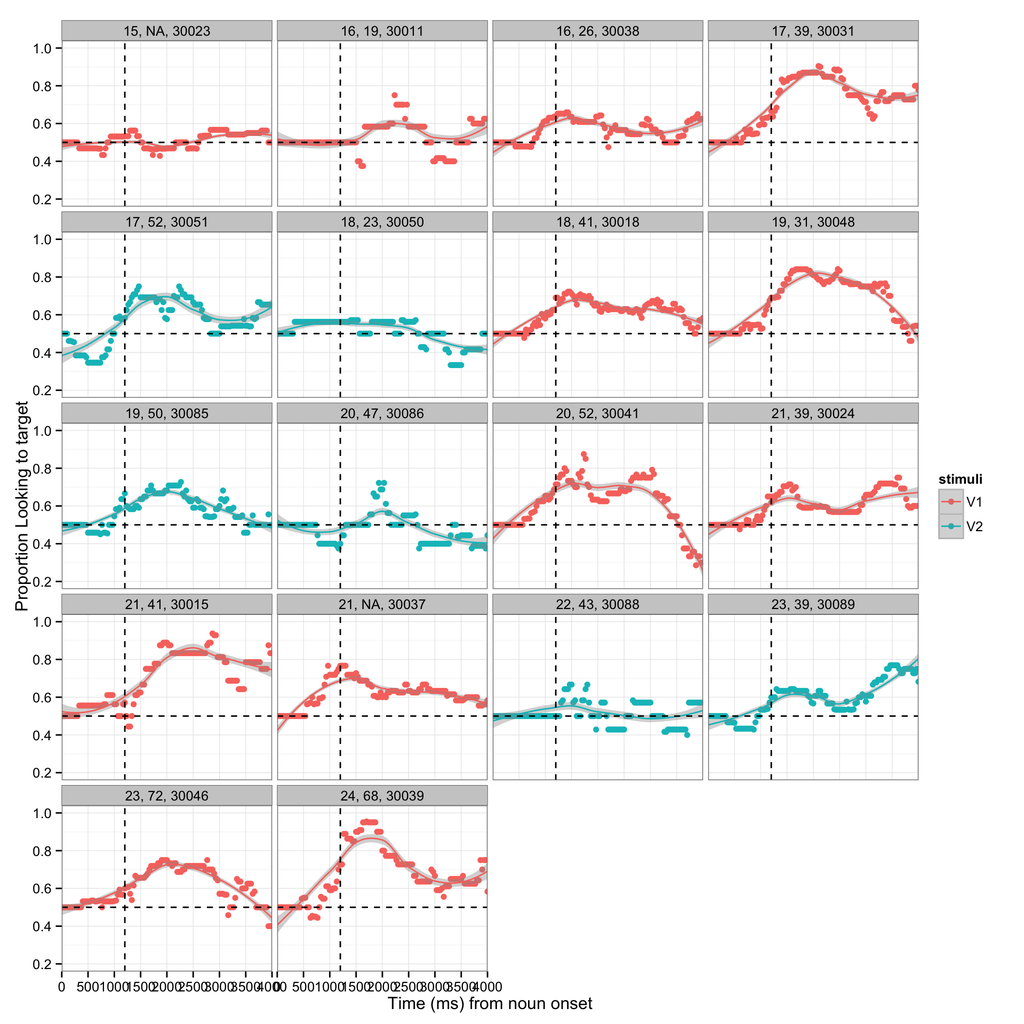

```r
# set breaks for x-axis
breaks <- seq(0,4000, by=500)

# younger
qplot(data = filter(ss.et.long, groupping == "< 25 Months"), x = Time.ms, y = accuracy,
      geom=c("point"), color=stimuli,
      ylim=c(0.2,1), xlab=c("Time (ms) from noun onset"),
      ylab=c("Proportion Looking to target")) +
    geom_smooth(method="loess") +
    geom_hline(yintercept = 0.5, linetype="dashed") +
    scale_x_discrete(breaks = breaks) +
    facet_wrap(age_months+signs_produced~Sub.Num, ncol=4) +
    #guides(color=FALSE) +
    geom_vline(xintercept=1200, linetype = "dashed") +
    theme(axis.text.x = element_text(angle = 75, hjust = 1)) +
    theme_bw()
```

Plot older kids

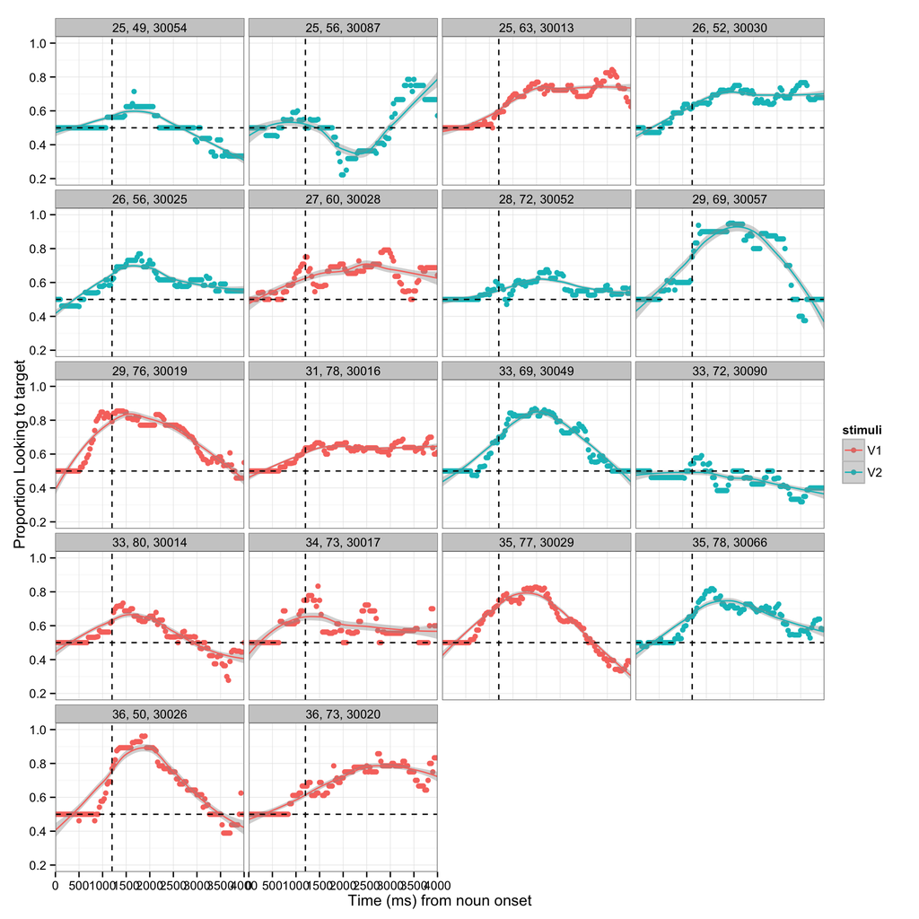

```r
qplot(data = filter(ss.et.long, groupping == "> 25 Months"), x = Time.ms, y = accuracy,
      geom=c("point"), color=stimuli,
      ylim=c(0.2,1), xlab=c("Time (ms) from noun onset"),
      ylab=c("Proportion Looking to target")) +
    geom_smooth(method="loess") +
    geom_hline(yintercept = 0.5, linetype="dashed") +
    scale_x_discrete(breaks = breaks) +
    facet_wrap(age_months+signs_produced~Sub.Num, ncol=4) +
    #guides(color=FALSE) +
    geom_vline(xintercept=1200, linetype = "dashed") +
    theme(axis.text.x = element_text(angle = 75, hjust = 1)) +
    theme_bw()
```

Plot adults

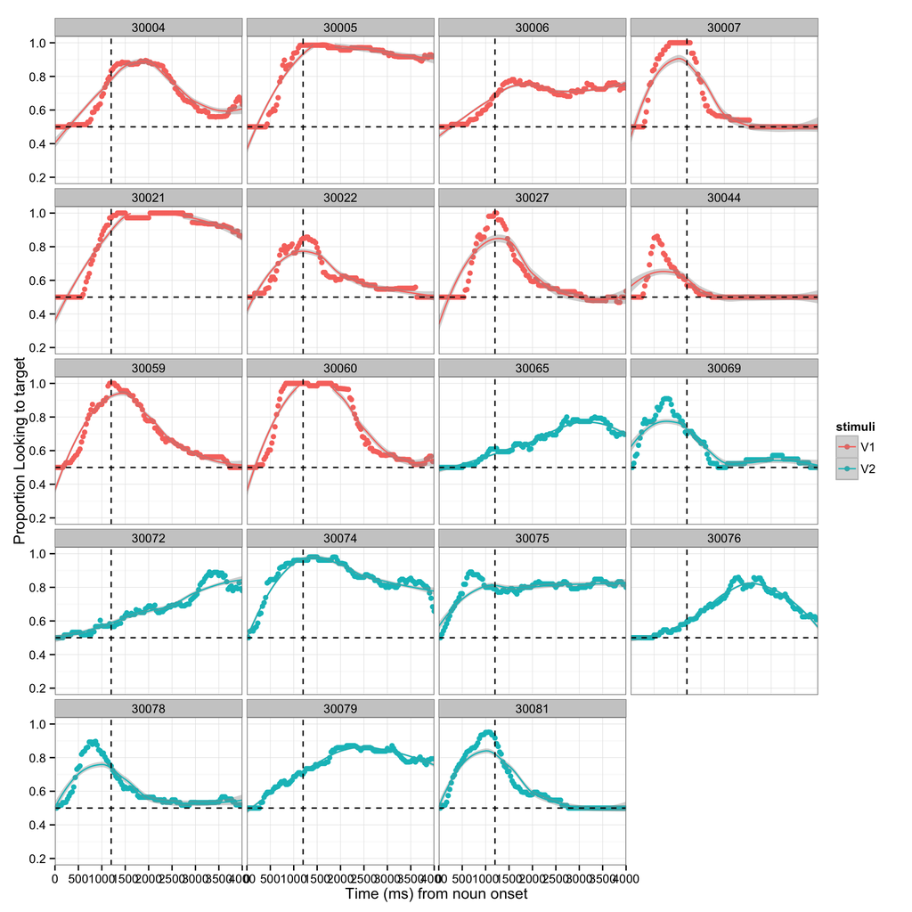

```r
qplot(data = filter(ss.et.long, groupping == "Adults"), x = Time.ms, y = accuracy,
      geom=c("point"), color=stimuli,
      ylim=c(0.2,1), xlab=c("Time (ms) from noun onset"),
      ylab=c("Proportion Looking to target")) +
    geom_smooth(method="loess") +
    geom_hline(yintercept = 0.5, linetype="dashed") +
    scale_x_discrete(breaks = breaks) +
    facet_wrap(~Sub.Num, ncol=4) +
    #guides(color=FALSE) +
    geom_vline(xintercept=1200, linetype = "dashed") +
    theme(axis.text.x = element_text(angle = 75, hjust = 1)) +
    theme_bw()
```